# IDS572-HW4

```
##
## Frequency Table of Program.Code :
##
##    CC    CD    HC    HD    HG    HN    HS   HVP    IC Other    SC    SG    SK
##    14   114   274  1433    25    73   131    62    12    69    46    20    68
##    SM    ST
##    23    28
```

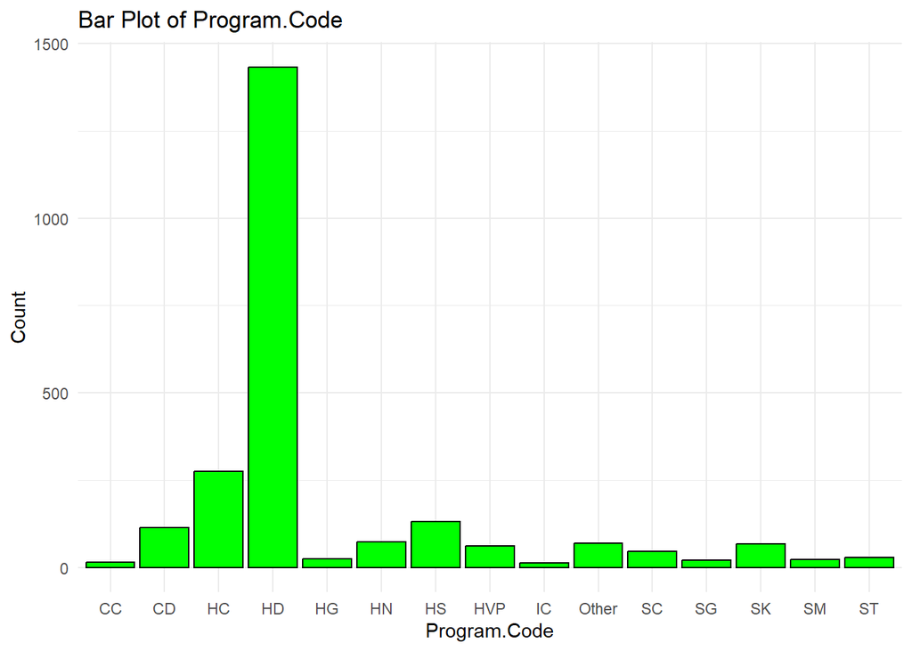

```
##
## Frequency Table of Group.State :
##
##    AL    AZ    CA    CO    CT    FL    GA    IA    ID    IL    IN    KS    KY
##    21    53   721    89    15    62    22    35    14   104    43    26    16
##    LA    MA    MD    MI    MN    MO    NC    NE    NM    NV    NY    OH    OK
##    31    36    15    71    51    43    16    42    20    20    19    53    33
##    OR Other    TN    TX    VA    WA    WI
##    51   113    38   308    18   147    46
```

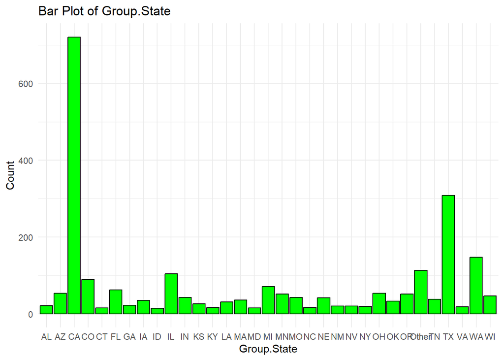

```
##
## Frequency Table of Travel.Type :
##
##     A     B Other
##  2017   367     8
```

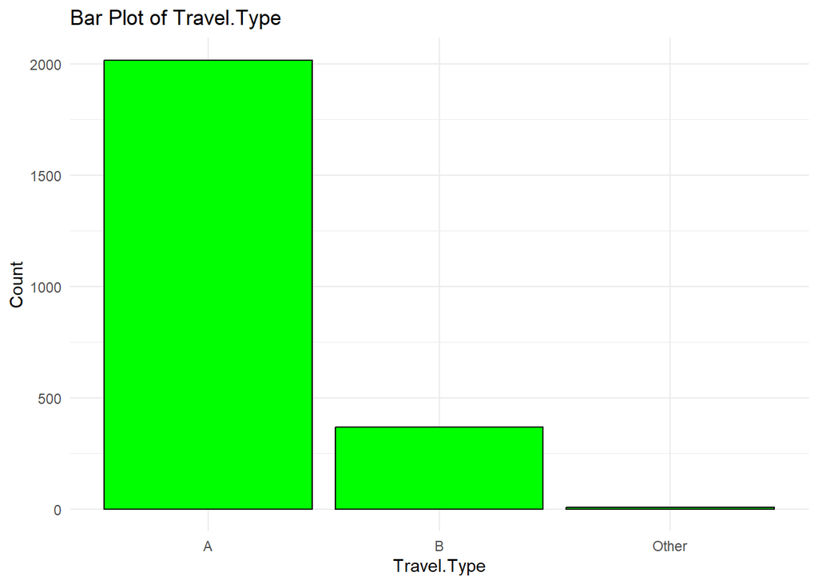

```
##
## Frequency Table of Special.Pay :
##
##   CP   FR   SA
##   70 2215  107
```

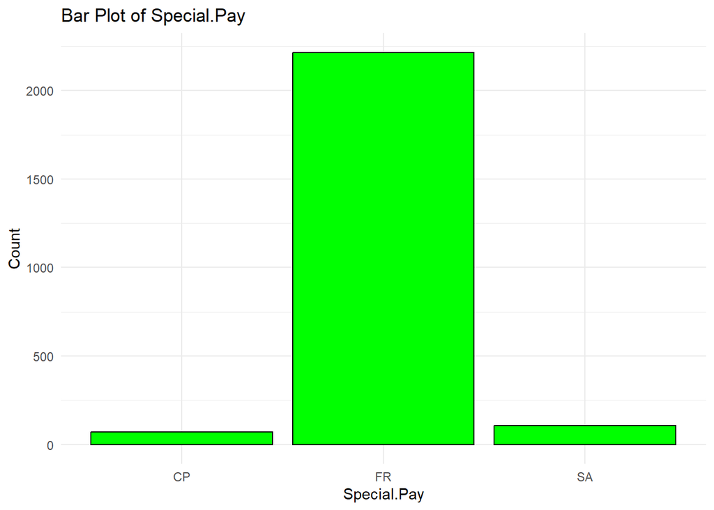

```
##
## Frequency Table of Poverty.Code :
##
##     A     B     C     D     E Other
##   265  1563   507    36    17     4
```

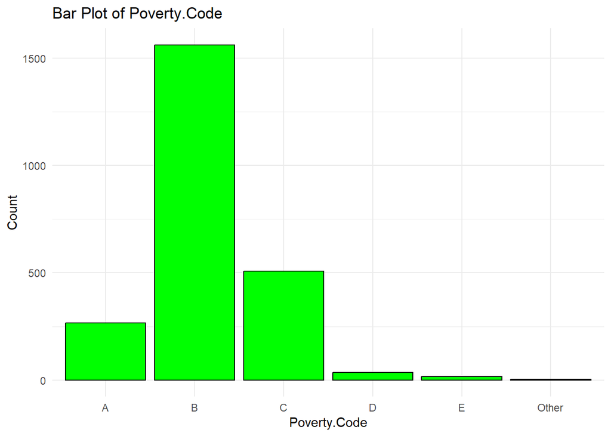

```
##
## Frequency Table of Region :
##
##              Dallas             Houston Northern California               Other
##                 163                 145                 275                1168
##   Pacific Northwest Southern California
##                 198                 443
```

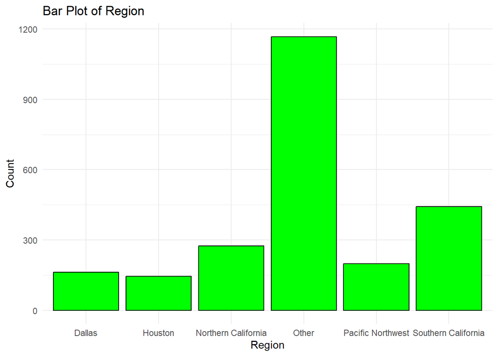

```
##
## Frequency Table of School.Type :
##
##              Catholic                   CHD Private non-Christian
##                   163                   257                   151
##                PUBLIC
##                  1821
```

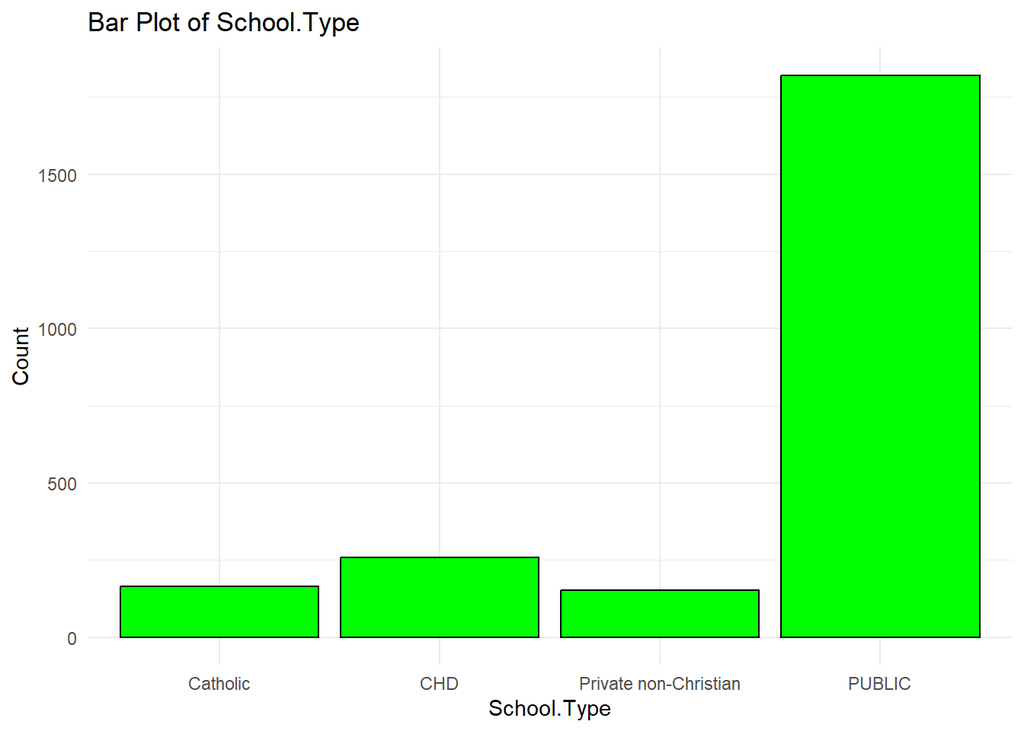

```
##
## Frequency Table of MDR.Low.Grade :
##
##     3     4     5     6     7     8     9     K Other    PK
##    12    17    96   959   348    14   104   428    13   401
```

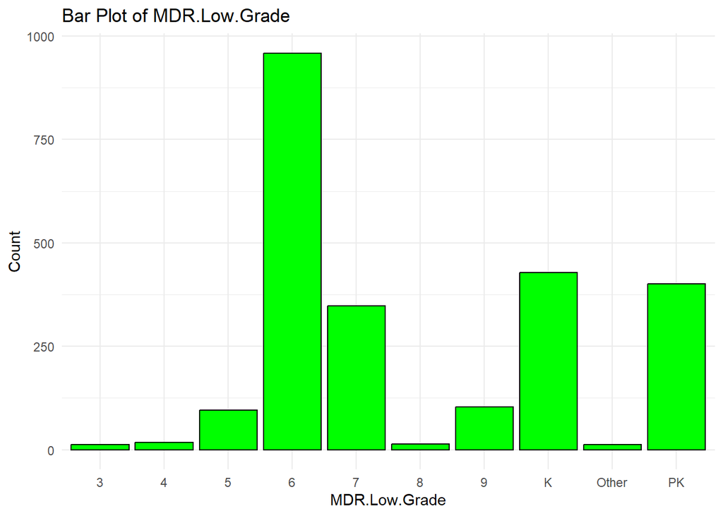

```
##
## Frequency Table of Income.Level :
##
##     A     B     C     D     E     F     G     H     I     J     K     L     M
##    20    33    67    41    80   105    91    85   159   160   123   214   189
##     N     O Other     P     Q     Z
##   148   266     7   212   348    44
```

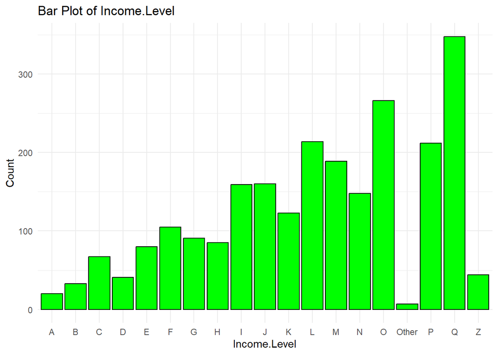

```
##
## Frequency Table of SPR.Product.Type :
##
##    CA History    Costa Rica    East Coast International         Other
##           175            46          2008            15             5
##       Science
##           143
```

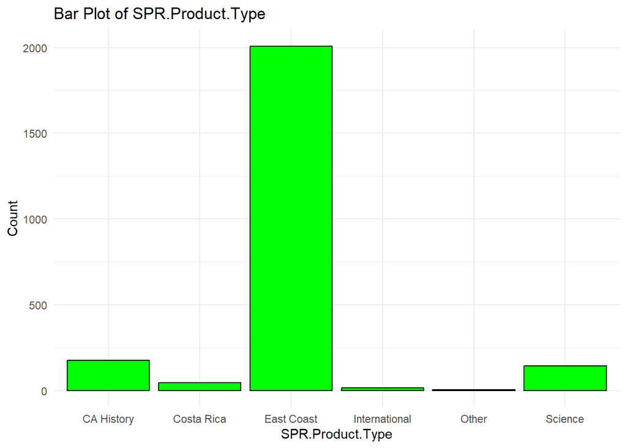

```
##
## Frequency Table of SPR.New.Existing :
##
## EXISTING      NEW
##     1610      782
```

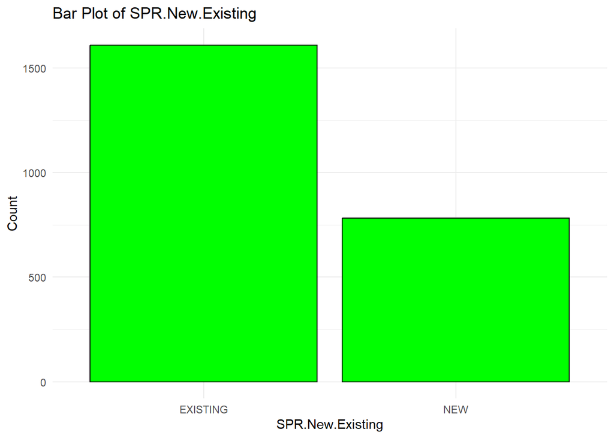

```
##
## Frequency Table of SchoolGradeTypeLow :
##
## Elementary       High     Middle  Undefined
##        259        141       1865        127
```

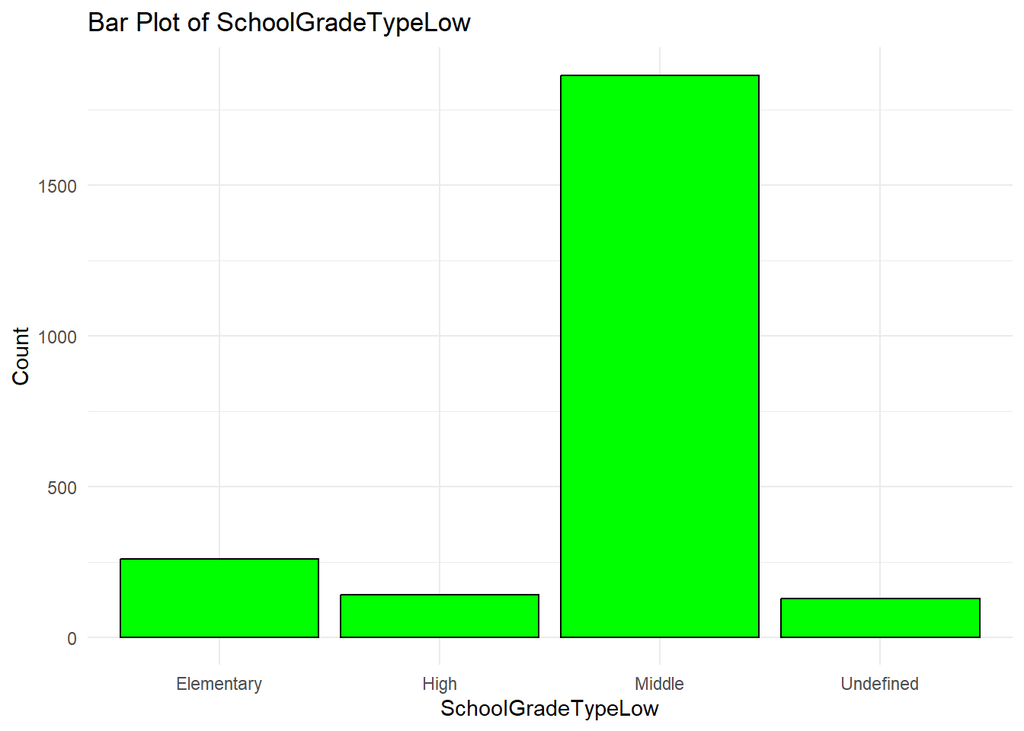

```
##
## Frequency Table of SchoolGradeTypeHigh :
##
## Elementary       High     Middle  Undefined
##        196        265       1781        150
```

[8 more figures not shown]

```r
for (col_name in character_columns) {
  cat("\nFrequency Table of", col_name, ":\n")
  print(table(data[[col_name]], useNA = "ifany"))  # Print frequency table

  # Plot bar chart
  print(
    ggplot(data, aes_string(x = col_name)) +
      geom_bar(fill = "green", color = "black") +
      labs(title = paste("Bar Plot of", col_name), x = col_name, y = "Count") +
      theme_minimal()
  )
}
```

#Multivariate Analysis Correlation Analysis Computed pairwise correlations between numeric variables.

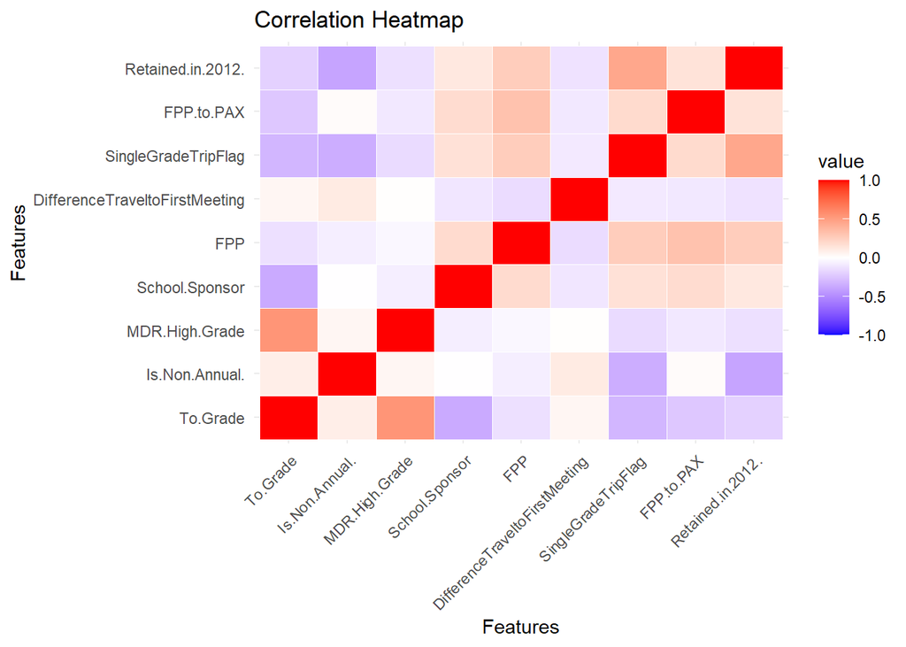

```r
# Correlation matrix
correlation_matrix <- cor(data[sapply(data, is.numeric)], use = "pairwise.complete.obs")

# Heatmap for visualization
library(reshape2)
correlation_melted <- melt(correlation_matrix)
ggplot(correlation_melted, aes(Var1, Var2, fill = value)) +
  geom_tile(color = "white") +
  scale_fill_gradient2(low = "blue", high = "red", mid = "white", midpoint = 0, limit = c(-1, 1)) +
  labs(title = "Correlation Heatmap", x = "Features", y = "Features") +
  theme_minimal() +
  theme(axis.text.x = element_text(angle = 45, hjust = 1))
```

#Scatter Plots relationships between “two numeric variables”DifferenceTraveltoFirstMeeting” and “Retained.in.2012.”.

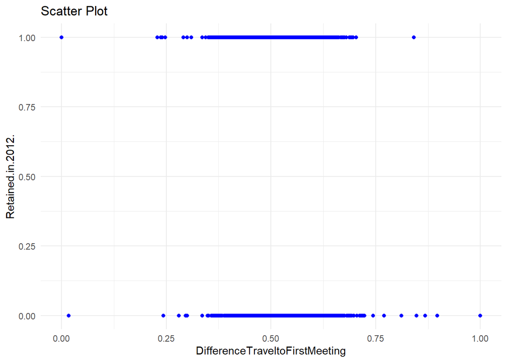

```r
# Scatter plot for two numeric variables
ggplot(data, aes(x = DifferenceTraveltoFirstMeeting, y = Retained.in.2012.)) +
  geom_point(color = "blue") +
  labs(title = "Scatter Plot", x = "DifferenceTraveltoFirstMeeting", y = "Retained.in.2012.") +
  theme_minimal()
```

Inferential Statistics

#T_test T-Test for All Numeric Variables

```r
# Ensure the target variable is a factor (required for grouping in t-test)
data$Retained.in.2012. <- as.factor(data$Retained.in.2012.)

# Identify numeric columns
numeric_columns <- names(data)[sapply(data, is.numeric)]

# Perform T-test for each numeric column
t_test_results <- lapply(numeric_columns, function(col) {
  test <- t.test(data[[col]] ~ data$Retained.in.2012., data = data)
  list(
    Variable = col,
    P_Value = test$p.value,
    Mean_Group_0 = test$estimate[1],
    Mean_Group_1 = test$estimate[2]
  )
})

# Convert results to a data frame for easy interpretation
t_test_summary <- do.call(rbind, lapply(t_test_results, as.data.frame))
t_test_summary <- as.data.frame(t_test_summary)

# View results
print(t_test_summary)
```

```
##                                        Variable       P_Value Mean_Group_0
## mean in group 0                        To.Grade  1.487033e-19   0.58694622
## mean in group 01                 Is.Non.Annual.  5.744928e-63   0.32942431
## mean in group 02                 MDR.High.Grade  8.336857e-10   0.69674355
## mean in group 03                 School.Sponsor  1.949151e-10   0.05970149
## mean in group 04                            FPP  8.938922e-46   0.06985195
## mean in group 05 DifferenceTraveltoFirstMeeting  1.074000e-08   0.49902004
## mean in group 06            SingleGradeTripFlag 6.537768e-120   0.27505330
## mean in group 07                     FPP.to.PAX  1.118602e-11   0.72950926
##                  Mean_Group_1
## mean in group 0    0.52040348
## mean in group 01   0.04057772
## mean in group 02   0.65430787
## mean in group 03   0.13548831
## mean in group 04   0.12458589
## mean in group 05   0.47968624
## mean in group 06   0.73933975
## mean in group 07   0.76600407
```

```r
# Save results to a CSV file
write.csv(t_test_summary, "T_Test_Results.csv", row.names = FALSE)
```

```r
# Perform ANOVA for each numeric column
anova_results <- lapply(numeric_columns, function(col) {
  formula <- as.formula(paste(col, "~ Retained.in.2012."))
  result <- aov(formula, data = data)
  summary_result <- summary(result)

  # Extract the p-value
  p_value <- summary_result[[1]]["Pr(>F)"][1]

  # Return variable, F-statistic, and p-value
  list(
    Variable = col,
    F_Value = summary_result[[1]]["F value"][1],
    P_Value = p_value
  )
})

# Convert results to a data frame
anova_summary <- do.call(rbind, lapply(anova_results, as.data.frame))
anova_summary <- as.data.frame(anova_summary)

# View results
print(anova_summary)
```

```
##                                          Variable   F.value        Pr..F.
## Retained.in.2012.                        To.Grade  93.44122  1.038787e-21
## Residuals                                To.Grade        NA            NA
## Retained.in.2012.1                 Is.Non.Annual. 430.96395  3.802842e-88
## Residuals        1                 Is.Non.Annual.        NA            NA
## Retained.in.2012.2                 MDR.High.Grade  42.65254  7.960111e-11
## Residuals        2                 MDR.High.Grade        NA            NA
## Retained.in.2012.3                 School.Sponsor  35.10376  3.577276e-09
## Residuals        3                 School.Sponsor        NA            NA
## Retained.in.2012.4                            FPP 174.31007  1.818712e-38
## Residuals        4                            FPP        NA            NA
## Retained.in.2012.5 DifferenceTraveltoFirstMeeting  36.09014  2.172071e-09
## Residuals        5 DifferenceTraveltoFirstMeeting        NA            NA
## Retained.in.2012.6            SingleGradeTripFlag 628.68106 2.273018e-123
## Residuals        6            SingleGradeTripFlag        NA            NA
## Retained.in.2012.7                     FPP.to.PAX  51.48735  9.572138e-13
## Residuals        7                     FPP.to.PAX        NA            NA
```

```r
# Save results to a CSV file
write.csv(anova_summary, "ANOVA_Test_Results.csv", row.names = FALSE)
```

All the variables listed are statistically significant because their p-values (Pr(>F)) are extremely small (e.g., 1.038787e-21, 3.802842e-88, etc.). SingleGradeTripFlag (F-value: 628.68, p-value: 2.273018e-123) has the highest F-value, suggesting the strongest group separation.

##Models to Apply

#Train-Test Split

```r
# Split data into training and testing sets (80-20 split)
set.seed(123)
train_index <- createDataPartition(data$Retained.in.2012., p = 0.8, list = FALSE)
train_data <- data[train_index, ]
test_data <- data[-train_index, ]
```

# Model Training and Evaluation

#Decision Tree:

```r
# Train Decision Tree
dt_model <- rpart(Retained.in.2012. ~ ., data = train_data, method = "class")

# Predict on test data
dt_predictions <- predict(dt_model, test_data, type = "class")

# Evaluate using confusion matrix
confusionMatrix(dt_predictions, test_data$Retained.in.2012.)
```

```
## Confusion Matrix and Statistics
##
##           Reference
## Prediction   0   1
##          0 125  31
##          1  62 259
##
##                Accuracy : 0.805
##                  95% CI : (0.7666, 0.8396)
##     No Information Rate : 0.608
##     P-Value [Acc > NIR] : < 2.2e-16
##
##                   Kappa : 0.5786
##
##  Mcnemar's Test P-Value : 0.001865
##
##             Sensitivity : 0.6684
##             Specificity : 0.8931
##          Pos Pred Value : 0.8013
##          Neg Pred Value : 0.8069
##              Prevalence : 0.3920
##          Detection Rate : 0.2621
##    Detection Prevalence : 0.3270
##       Balanced Accuracy : 0.7808
##
##        'Positive' Class : 0
##
```

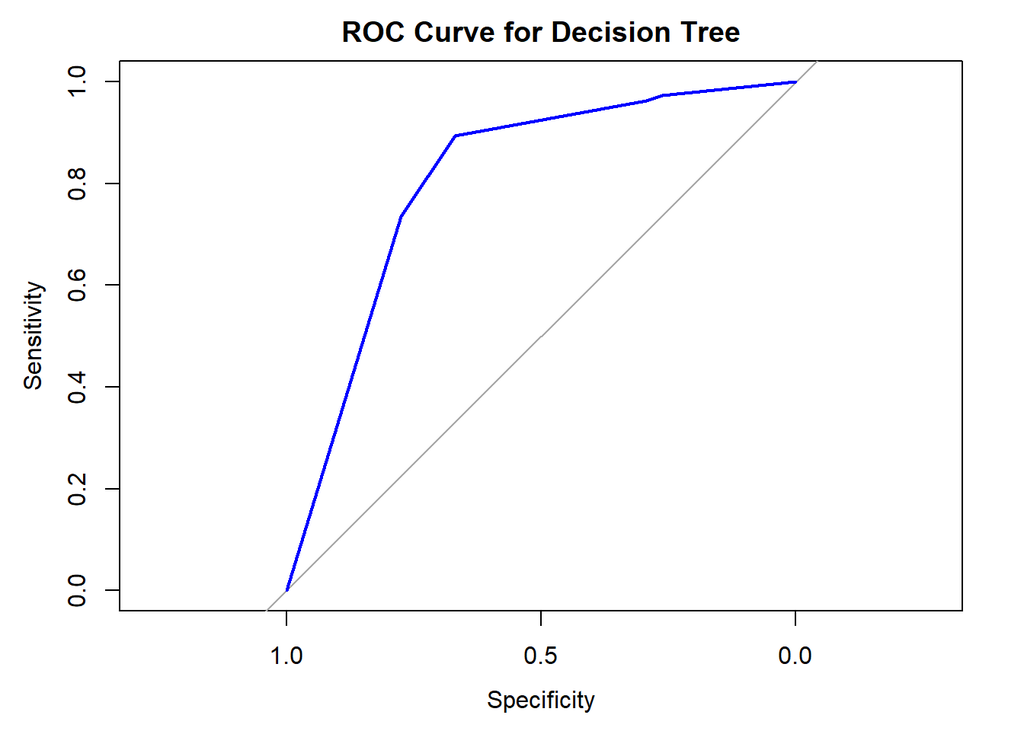

```r
# Get predicted probabilities for the positive class (e.g., class `1`)
dt_probabilities <- predict(dt_model, test_data, type = "prob")[, 2]

# Plot ROC Curve
dt_roc <- roc(test_data$Retained.in.2012., dt_probabilities)
plot(dt_roc, col = "blue", main = "ROC Curve for Decision Tree")
```

```r
auc(dt_roc)  # Print AUC value
```

```
## Area under the curve: 0.8062
```

Decision Tree

Strengths: Highest accuracy (0.805) and precision (0.8013), meaning it performs slightly better overall in correctly classifying both classes. Highest specificity (0.8931): Best at correctly identifying class 1. Balanced accuracy (0.7808) indicates good performance on both classes.

Weaknesses: Lowest sensitivity (0.6684): Performs poorly in identifying class 0. McNemar’s test p-value (0.001865) suggests significant bias, likely favoring class 1. Lowest AUC (0.8062): Indicates relatively weaker ability to discriminate between classes.

#random Forest

```r
# Train Random Forest
rf_model <- randomForest(Retained.in.2012. ~ ., data = train_data)

# Predict on test data
rf_predictions <- predict(rf_model, test_data)

# Evaluate using confusion matrix
confusionMatrix(rf_predictions, test_data$Retained.in.2012.)
```

```
## Confusion Matrix and Statistics
##
##           Reference
## Prediction   0   1
##          0 127  38
##          1  60 252
##
##                Accuracy : 0.7945
##                  95% CI : (0.7555, 0.8299)
##     No Information Rate : 0.608
##     P-Value [Acc > NIR] : < 2e-16
##
##                   Kappa : 0.5598
##
##  Mcnemar's Test P-Value : 0.03389
##
##             Sensitivity : 0.6791
##             Specificity : 0.8690
##          Pos Pred Value : 0.7697
##          Neg Pred Value : 0.8077
##              Prevalence : 0.3920
##          Detection Rate : 0.2662
##    Detection Prevalence : 0.3459
##       Balanced Accuracy : 0.7741
##
##        'Positive' Class : 0
##
```

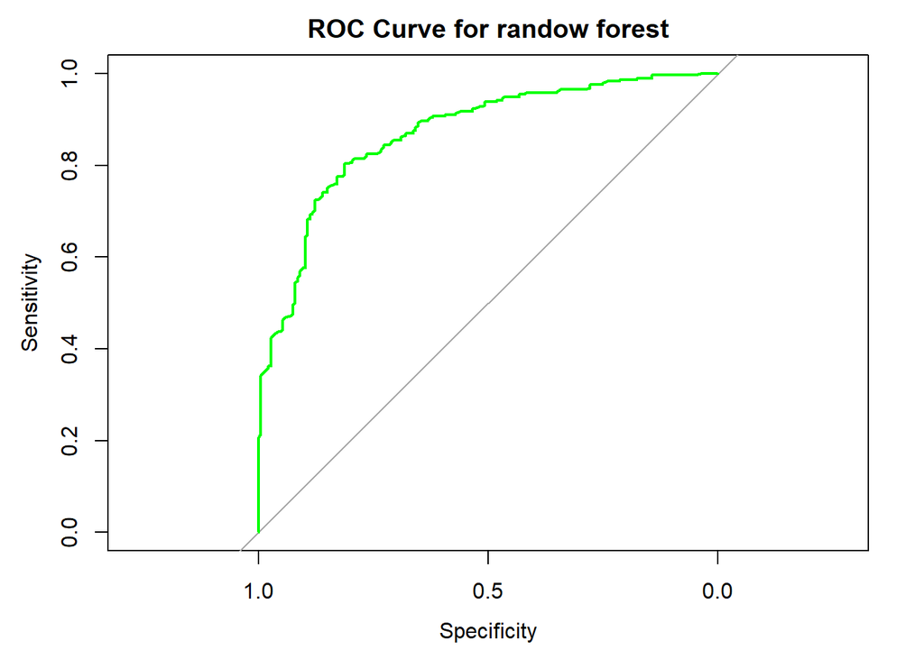

```r
# Get predicted probabilities for the positive class (e.g., class `1`)
rf_probabilities <- predict(rf_model, test_data, type = "prob")[, 2]

# Plot ROC Curve
rf_roc <- roc(test_data$Retained.in.2012., rf_probabilities)
plot(rf_roc, col = "green" , main = "ROC Curve for randow forest")  # Add to the same plot
```

```r
auc(rf_roc)  # Print AUC value
```

```
## Area under the curve: 0.8692
```

Random Forest

#Naive Bayes:

```r
# Train Naive Bayes
nb_model <- naiveBayes(Retained.in.2012. ~ ., data = train_data)

# Predict on test data
nb_predictions <- predict(nb_model, test_data)

# Evaluate using confusion matrix
confusionMatrix(nb_predictions, test_data$Retained.in.2012.)
```

```
## Confusion Matrix and Statistics
##
##           Reference
## Prediction   0   1
##          0 132  44
##          1  55 246
##
##                Accuracy : 0.7925
##                  95% CI : (0.7532, 0.828)
##     No Information Rate : 0.608
##     P-Value [Acc > NIR] : <2e-16
##
##                   Kappa : 0.56
##
##  Mcnemar's Test P-Value : 0.3149
##
##             Sensitivity : 0.7059
##             Specificity : 0.8483
##          Pos Pred Value : 0.7500
##          Neg Pred Value : 0.8173
##              Prevalence : 0.3920
##          Detection Rate : 0.2767
##    Detection Prevalence : 0.3690
##       Balanced Accuracy : 0.7771
##
##        'Positive' Class : 0
##
```

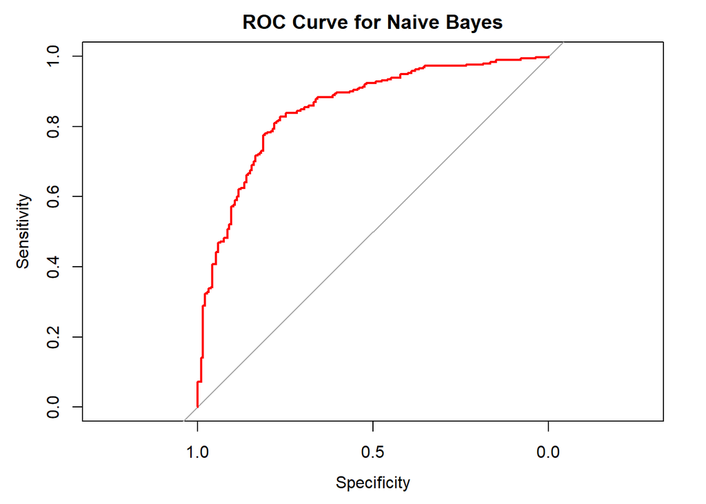

```r
# Get predicted probabilities for the positive class (e.g., class `1`)
nb_probabilities <- predict(nb_model, test_data, type = "raw")[, 2]

# Plot ROC Curve
nb_roc <- roc(test_data$Retained.in.2012., nb_probabilities)
plot(nb_roc, col = "red", main = "ROC Curve for Naive Bayes")  # Add to the same plot
```

```r
auc(nb_roc)  # Print AUC value
```

```
## Area under the curve: 0.8507
```

Naive Bayes Analyse

Strengths: Highest sensitivity (0.7059): Best at identifying class 0 cases. AUC (0.8507) slightly edges out Logistic Regression. Balanced accuracy (0.7771) is higher than Logistic Regression. McNemar’s test p-value (0.3149): No significant class bias.

Weaknesses: Slightly lower precision (0.7500): More false positives compared to other models. Specificity (0.8483) is lower than other models, indicating slightly less accuracy in identifying class 1.

#Logistic Regression

```r
# Train Logistic Regression
lr_model <- glm(Retained.in.2012. ~ ., data = train_data, family = "binomial")

# Predict probabilities on test data
lr_probabilities <- predict(lr_model, test_data, type = "response")
# Convert probabilities to class predictions
lr_predictions <- ifelse(lr_probabilities > 0.5, 1, 0)

# Evaluate using confusion matrix
confusionMatrix(as.factor(lr_predictions), test_data$Retained.in.2012.)
```

```
## Confusion Matrix and Statistics
##
##           Reference
## Prediction   0   1
##          0 127  39
##          1  60 251
##
##                Accuracy : 0.7925
##                  95% CI : (0.7532, 0.828)
##     No Information Rate : 0.608
##     P-Value [Acc > NIR] : < 2e-16
##
##                   Kappa : 0.5557
##
##  Mcnemar's Test P-Value : 0.04442
##
##             Sensitivity : 0.6791
##             Specificity : 0.8655
##          Pos Pred Value : 0.7651
##          Neg Pred Value : 0.8071
##              Prevalence : 0.3920
##          Detection Rate : 0.2662
##    Detection Prevalence : 0.3480
##       Balanced Accuracy : 0.7723
##
##        'Positive' Class : 0
##
```

```r
# Use predicted probabilities from the logistic regression model
lr_probabilities <- predict(lr_model, test_data, type = "response")
```

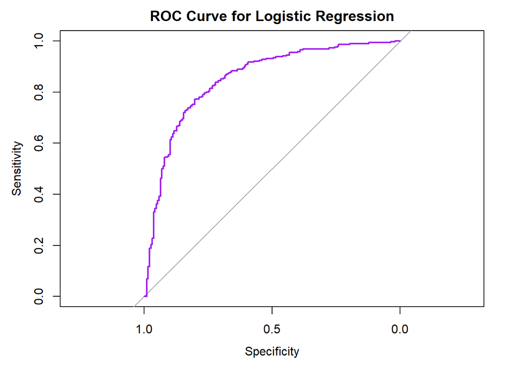

```r
# Plot ROC Curve
lr_roc <- roc(test_data$Retained.in.2012., lr_probabilities)
plot(lr_roc, col = "purple", main = "ROC Curve for Logistic Regression")  # Add to the same plot
```

```r
auc(lr_roc)  # Print AUC value
```

```
## Area under the curve: 0.8504
```

Logistic Regression analyse

__Strengths: AUC of 0.8504 shows strong discrimination capability. High specificity (0.8655): Effective in correctly identifying class 1. Balanced accuracy (0.7723) indicates reasonable performance across both classes. __Weaknesses: Moderate sensitivity (0.6791): Misses ~32% of actual class 0 cases. McNemar’s test p-value (0.04442) suggests a significant difference in error rates between classes, indicating potential bias.

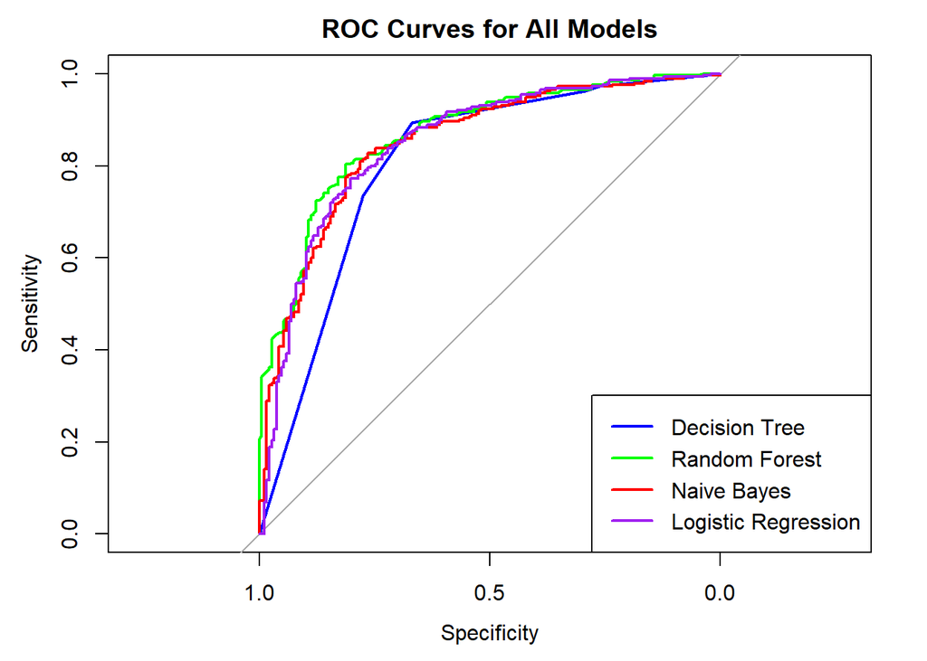

```r
# Plot Decision Tree ROC
plot(dt_roc, col = "blue", main = "ROC Curves for All Models", lwd = 2)

# Add other models' ROC curves
plot(rf_roc, col = "green", add = TRUE, lwd = 2)
plot(nb_roc, col = "red", add = TRUE, lwd = 2)
plot(lr_roc, col = "purple", add = TRUE, lwd = 2)


# Add a legend
legend("bottomright", legend = c("Decision Tree", "Random Forest", "Naive Bayes", "Logistic Regression"),
       col = c("blue", "green", "red", "purple"), lwd = 2)
```

ROC Curve Analyst: The ROC curve compares the True Positive Rate (Sensitivity) against the False Positive Rate (1 - Specificity) for each model.

Decision Tree (Blue):

This curve is noticeably lower than the others, indicating it is the least effective model in separating the two classes. The AUC for this model is the smallest, reflecting relatively weaker performance compared to the others. Random Forest (Green):

The Naive Bayes curve closely follows Random Forest and Logistic Regression. Its performance is slightly lower than Random Forest but still competitive, with a strong AUC score. Logistic Regression (Purple):

Logistic Regression is similar to Naive Bayes and slightly below Random Forest. The AUC is competitive, though slightly lower than Random Forest, indicating strong but not the best overall performance.

> > Secondary Choice: Naive Bayes Naive Bayes achieves the highest sensitivity (0.7059) and a competitive AUC (0.8507), making it a good option if identifying class 0 (minimizing false negatives) is critical.